# CO2 Data Project

As part of this project, your task will be to familiarise yourself with the plant dataset CO2 by doing a few helpful visualizations and even some basic statistical analyses.

The CO2 data frame is part of **R base** and contains data from an experiment on the cold tolerance of the grass species *Echinochloa crus-galli*. The CO2 uptake of six plants from Quebec and six plants from Mississippi was measured at several levels of CO2 ambient concentration. Half the plants of each type were chilled overnight before the experiment was conducted.

Here's a preview:

`str(CO2)` `: 84 obs. of 5 variables:` `$ Plant : Ord.factor w/ 12 levels "Qn1"<"Qn2"<"Qn3"<..: 1 1 1 1 1 1 1 2 2 2 ...` `$ Type : Factor w/ 2 levels "Quebec","Mississippi": 1 1 1 1 1 1 1 1 1 1 ...` `$ Treatment: Factor w/ 2 levels "nonchilled","chilled": 1 1 1 1 1 1 1 1 1 1 ...` `$ conc : num 95 175 250 350 500 675 1000 95 175 250 ...` `$ uptake : num 16 30.4 34.8 37.2 35.3 39.2 39.7 13.6 27.3 37.1 ...`

Although the data might look boring at first, its strength lies in the fact that it has a low level of complexity, it's clean and allows for:

- Cool and helpful visualisations
- Introduction to hypothesis testing and analysis of variance (ANOVA)

Your tasks would therefore be the following:

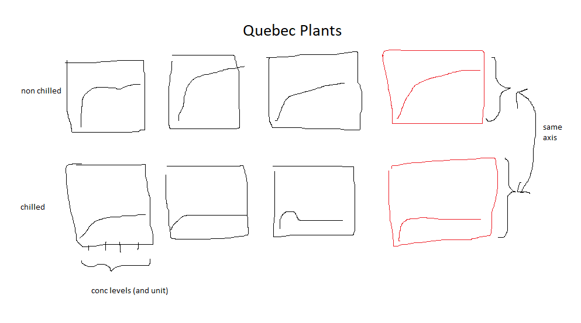

This should help give an intuition about effects in the data. You are free to plot other conditions as well.

- After this, formulate some hypotheses (e.g. “plant 1 has a higher CO2 uptake than all other plants”)
- Learn to perform hypothesis tests to prove your hypotheses in a scientificaly accurate way
- Build a new visualization containing more than one plot, with the help of which you can easily communicate your statistical findings to a nonprofessional
- (BONUS) If you find this fun and want to deepen your understanding of statistical testing, also test your hypotheses using analyses of variance (ANOVA)

I offer to help with any questions regarding the statistical part.

[output not shown]